# Application de l'ACP

L'utilisation combinée de la **PCA (Analyse en Composantes Principales)** et du **CAH (Classification Ascendante Hiérarchique)** pour la base de données **Heart Disease** permet d'extraire des **informations cachées**, de **réduire la complexité**, et de **mieux comprendre les profils de patients**.

**1. Intérêt de la PCA (Analyse en Composantes Principales)**

**a. Réduction de dimension**

- La base contient plusieurs variables : âge, sexe, cholestérol, pression artérielle, ECG, fréquence cardiaque, etc.
- La PCA permet de **réduire le nombre de dimensions** tout en conservant un maximum de variance (information).

**b. Visualisation**

- En ramenant les données à 2 ou 3 dimensions principales, on peut **visualiser la population de patients** et observer les regroupements naturels.

**c. Détection de corrélations**

- La PCA révèle quelles variables sont **corrélées entre elles**, ce qui est utile pour comprendre les facteurs qui évoluent ensemble dans les cas de maladies cardiaques.

**2. Intérêt du CAH (Classification Ascendante Hiérarchique)**

**a. Regroupement des patients**

- Le CAH permet d’**identifier des groupes de patients ayant des profils médicaux similaires** (par exemple : jeunes sans facteurs de risque, seniors avec antécédents, etc.).

**b. Aide au diagnostic**

- Ces clusters peuvent être associés à des **niveaux de risque de maladie cardiaque**, ce qui aide les médecins à adapter la prévention.

**c. Représentation visuelle par dendrogramme**

- Le dendrogramme CAH permet de **visualiser la hiérarchie des regroupements** entre patients.

```python
!pip install faker scikit-learn seaborn
```

```python
# Importation des bibliothèques nécessaires
import pandas as pd
import numpy as np
from faker import Faker
from sklearn.decomposition import PCA
import matplotlib.pyplot as plt
import seaborn as sns
import matplotlib.cm as cm

# Chargement des données
file_path = 'HeartDiseaseUCI.csv'  # Remplacez ce chemin par celui de vos données
data = pd.read_csv(file_path)

# Aperçu des données
print("Aperçu des données :")
data.head()
```

```
Aperçu des données :
```

|  | Unnamed: 0 | age | sex | cp | trestbps | chol | fbs | restecg | thalach | exang | oldpeak | slope | ca | thal | num |
| --- | --- | --- | --- | --- | --- | --- | --- | --- | --- | --- | --- | --- | --- | --- | --- |
| 0 | 1 | 63 | 1 | 1 | 145 | 233 | 1 | 2 | 150 | 0 | 2.3 | 3 | 0.0 | 6.0 | 0 |
| 1 | 2 | 67 | 1 | 4 | 160 | 286 | 0 | 2 | 108 | 1 | 1.5 | 2 | 3.0 | 3.0 | 2 |
| 2 | 3 | 67 | 1 | 4 | 120 | 229 | 0 | 2 | 129 | 1 | 2.6 | 2 | 2.0 | 7.0 | 1 |
| 3 | 4 | 37 | 1 | 3 | 130 | 250 | 0 | 0 | 187 | 0 | 3.5 | 3 | 0.0 | 3.0 | 0 |
| 4 | 5 | 41 | 0 | 2 | 130 | 204 | 0 | 2 | 172 | 0 | 1.4 | 1 | 0.0 | 3.0 | 0 |

C'est une base de donnees sur les maladies cardiaques, souvent référencé dans des études de machine learning, contient généralement des informations recueillies auprès de patients pour prédire la présence d'une maladie cardiaque. Voici une description des variables couramment trouvées dans de tels datasets :

1. **age** : L'âge du patient en années.
2. **sex** : Le sexe du patient (généralement codé comme 1 = homme, 0 = femme).
3. **cp** (chest pain type) : Type de douleur thoracique (valeurs typiques incluent 1 = angine typique, 2 = angine atypique, 3 = douleur non angineuse, 4 = asymptomatique).
4. **trestbps** (resting blood pressure) : La tension artérielle au repos en mm Hg (millimètres de mercure) lors de l'admission à l'hôpital.
5. **chol** (serum cholesterol) : Le cholestérol sérique en mg/dl (milligrammes par décilitre).
6. **fbs** (fasting blood sugar) : Le taux de sucre dans le sang à jeun > 120 mg/dl (1 = vrai ; 0 = faux).
7. **restecg** (resting electrocardiographic results) : Résultats de l'électrocardiogramme au repos (valeurs telles que 0 = normal, 1 = ayant des anomalies de l'onde ST-T, 2 = montrant une hypertrophie ventriculaire gauche probable ou définitive selon les critères d'Estes).
8. **thalach** (maximum heart rate achieved) : Fréquence cardiaque maximale atteinte.
9. **exang** (exercise induced angina) : Angine déclenchée par l'exercice (1 = oui ; 0 = non).
10. **oldpeak** (ST depression induced by exercise relative to rest) : Dépression du segment ST induite par l'exercice par rapport au repos.
11. **slope** (the slope of the peak exercise ST segment) : La pente du segment ST d'effort (valeurs telles que 1 = pente ascendante, 2 = plat, 3 = pente descendante).
12. **ca** (number of major vessels colored by flourosopy) : Nombre de vaisseaux principaux (0-3) colorés par fluoroscopie.
13. **thal** (thalassemia) : Une anomalie de l'hémoglobine (3 = normal ; 6 = défaut fixe ; 7 = défaut réversible).
14. **num** : Présence de maladie cardiaque (0 = absence, sinon presence avec des degrés).

```python
# Renommage des colonnes pour les rendre accessibles
data.rename(columns={
    "age": "Age",  # Âge de la personne
    "sex": "Genre",  # Sexe (0 = femme, 1 = homme)
    "cp": "Douleur_poitrine",  # Type de douleur ressentie dans la poitrine
    "trestbps": "Pression_artérielle",  # Pression artérielle mesurée au repos
    "chol": "Cholestérol",  # Niveau de cholestérol dans le sang
    "fbs": "Sucre",  # Si le taux de sucre à jeun est supérieur à 120 mg/dl (1 = oui)
    "restecg": "Résultat_test_cœur",  # Résultat de l'activité électrique du cœur mesurée au repos
    "thalach": "Fréquence_cardiaque_max",  # Fréquence cardiaque maximale atteinte à l’effort
    "exang": "Douleur_effort",  # Si la personne ressent une douleur à l'effort (1 = oui)
    "oldpeak": "alerte_effort",  # Mesure de l’écart du signal cardiaque à l’effort (inquiétant si elevé)
    "slope": "signal_effort",  # Manière dont le tracé cardiaque évolue pendant l’effort (forme de la courbe)
    "ca": "Vaisseaux visibles",  # Nombre de vaisseaux sanguins visibles lors d’un examen (fluoroscopie)
    "thal": "Anomalie_cardiaque",  # Type d'anomalie détectée (valeurs : 3 = normal, 6 = fixe, 7 = réversible)
    "num": "Cardiaque"  # 1 = la personne a une maladie cardiaque, 0 = non
}, inplace=True)

# Affichage des premières lignes du dataset renommé
data.head()
```

|  | Unnamed: 0 | Age | Genre | Douleur_poitrine | Pression_artérielle | Cholestérol | Sucre | Résultat_test_cœur | Fréquence_cardiaque_max | Douleur_effort | alerte_effort | signal_effort | Vaisseaux visibles | Anomalie_cardiaque | Cardiaque |
| --- | --- | --- | --- | --- | --- | --- | --- | --- | --- | --- | --- | --- | --- | --- | --- |
| 0 | 1 | 63 | 1 | 1 | 145 | 233 | 1 | 2 | 150 | 0 | 2.3 | 3 | 0.0 | 6.0 | 0 |
| 1 | 2 | 67 | 1 | 4 | 160 | 286 | 0 | 2 | 108 | 1 | 1.5 | 2 | 3.0 | 3.0 | 2 |
| 2 | 3 | 67 | 1 | 4 | 120 | 229 | 0 | 2 | 129 | 1 | 2.6 | 2 | 2.0 | 7.0 | 1 |
| 3 | 4 | 37 | 1 | 3 | 130 | 250 | 0 | 0 | 187 | 0 | 3.5 | 3 | 0.0 | 3.0 | 0 |
| 4 | 5 | 41 | 0 | 2 | 130 | 204 | 0 | 2 | 172 | 0 | 1.4 | 1 | 0.0 | 3.0 | 0 |

```python
# Initialisation de Faker pour ajouter des prénoms
from faker import Faker

from faker import Faker

fake = Faker("fr_FR")
# Fonction pour générer des prénoms basés sur le genre

data.index=data['Genre'].apply(lambda x:
                  fake.first_name_male() if x== 1
                  else fake.first_name_female())
```

```python
data
```

| Genre | Unnamed: 0 | Age | Genre | Douleur_poitrine | Pression_artérielle | Cholestérol | Sucre | Résultat_test_cœur | Fréquence_cardiaque_max | Douleur_effort | alerte_effort | signal_effort | Vaisseaux visibles | Anomalie_cardiaque | Cardiaque |
| --- | --- | --- | --- | --- | --- | --- | --- | --- | --- | --- | --- | --- | --- | --- | --- |
| Marc | 1 | 63 | 1 | 1 | 145 | 233 | 1 | 2 | 150 | 0 | 2.3 | 3 | 0.0 | 6.0 | 0 |
| Benoît | 2 | 67 | 1 | 4 | 160 | 286 | 0 | 2 | 108 | 1 | 1.5 | 2 | 3.0 | 3.0 | 2 |
| Gérard | 3 | 67 | 1 | 4 | 120 | 229 | 0 | 2 | 129 | 1 | 2.6 | 2 | 2.0 | 7.0 | 1 |
| Guillaume | 4 | 37 | 1 | 3 | 130 | 250 | 0 | 0 | 187 | 0 | 3.5 | 3 | 0.0 | 3.0 | 0 |
| Julie | 5 | 41 | 0 | 2 | 130 | 204 | 0 | 2 | 172 | 0 | 1.4 | 1 | 0.0 | 3.0 | 0 |
| ... | ... | ... | ... | ... | ... | ... | ... | ... | ... | ... | ... | ... | ... | ... | ... |
| Victor | 299 | 45 | 1 | 1 | 110 | 264 | 0 | 0 | 132 | 0 | 1.2 | 2 | 0.0 | 7.0 | 1 |
| David | 300 | 68 | 1 | 4 | 144 | 193 | 1 | 0 | 141 | 0 | 3.4 | 2 | 2.0 | 7.0 | 2 |
| Yves | 301 | 57 | 1 | 4 | 130 | 131 | 0 | 0 | 115 | 1 | 1.2 | 2 | 1.0 | 7.0 | 3 |
| Marthe | 302 | 57 | 0 | 2 | 130 | 236 | 0 | 2 | 174 | 0 | 0.0 | 2 | 1.0 | 3.0 | 1 |
| Daniel | 303 | 38 | 1 | 3 | 138 | 175 | 0 | 0 | 173 | 0 | 0.0 | 1 | NaN | 3.0 | 0 |

303 rows × 15 columns

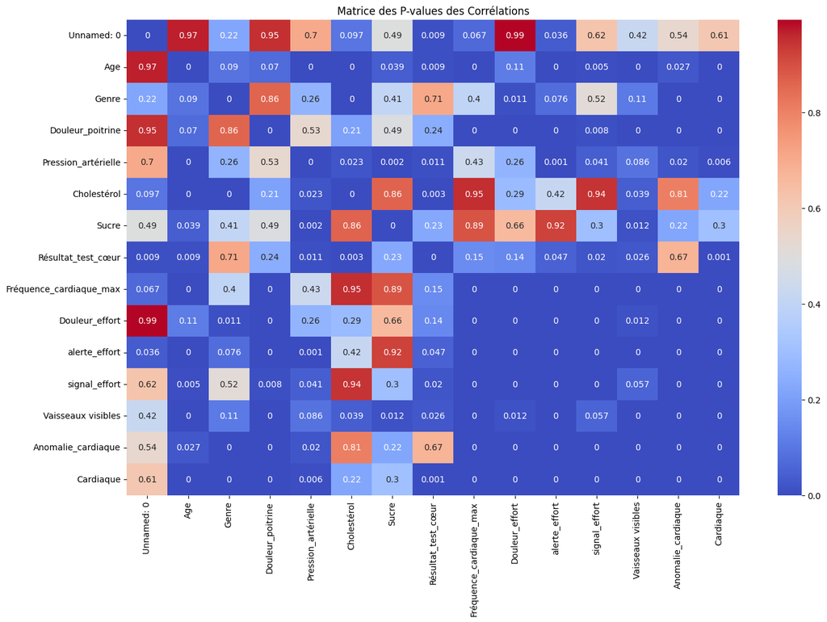

```python
# Fonction pour calculer la matrice des p-values
import numpy as np
import scipy.stats as stats

def calculate_pvalues(df):
    df = df.select_dtypes(include=[np.number])
    pvalues = pd.DataFrame(np.ones((df.shape[1], df.shape[1])), columns=df.columns, index=df.columns)

    for col1 in df.columns:
        for col2 in df.columns:
            if col1 != col2:
                _, pval = stats.pearsonr(df[col1], df[col2])
                pvalues.loc[col1, col2] = pval
            else:
                pvalues.loc[col1, col2] = 0  # p-value = 0 pour la corrélation avec soi-même
    return pvalues

# Calcul des p-values

moyenne=data.mean(numeric_only=True)
data= data.fillna(moyenne) #je remplace les donnees manquantes par les moyennes
pval_matrix = calculate_pvalues(data)

# Visualisation de la matrice de p-values
plt.figure(figsize=(16, 10))
sns.heatmap(pval_matrix.round(3), annot=True, cmap="coolwarm", cbar=True)
plt.title("Matrice des P-values des Corrélations")
plt.show()
```